# HW5 - Problem 3 - Orange Juice classification

misken

March 26, 2018

# Problem 3 - Predicting orange juice purchases

The dataset is available as part of the ISLR package. You can see the documentation for that package or the following link describes the OJ dataset - https://rdrr.io/cran/ISLR/man/OJ.html.

**SUGGESTION**: See the material available in Downloads_StatModels2 from the session on classification models in R. In particular, the folder on logistic regression and the example in the folder intro_class_HR/ will be useful.

## Data prep

We’ll do a little data prep to set things up so that we are trying to predict whether or not the customer purchased Minute Maid (vs Citrus Hill.) Just run the following chunks to load the dataset, do some data prep and then partition the data into training and test sets.

```r
library(ISLR)
ojsales <- (ISLR::OJ)
```

Clean up the storeid related fields. Drop Store7 field.

```r
ojsales$StoreID <- as.factor(ojsales$StoreID)

# Create a new variable to act as the response variable.
ojsales$MM <- as.factor(ifelse(ojsales$Purchase=="MM",1,0))
```

Now we’ll just take a subset of the columns as there are a few that contain the same information. Remember, the new column `MM` is the one we are trying to predict.

```r
ojsales_subset <- ojsales[, c(19, 3:13, 15:17)]
```

Just run this chunk to create training and test datasets. This way we’ll all be working with the same datasets. Notice that the test set is 10% of the full dataset.

```r
set.seed(167)
sample_size <- ceiling(0.10 * nrow(ojsales))
testrecs <- sample(nrow(ojsales_subset),sample_size)
ojsales_test <- ojsales_subset[testrecs,]
ojsales_train <- ojsales_subset[-testrecs,]  # Negative in front of vector means "not in"
rm(ojsales_subset, ojsales) # No sense keeping a copy of the entire dataset around
```

## Your job

You should build at least two classification models to try to predict MM. Our error metric will be overall accuracy.

Obviously, `ojsales_train` is your training dataset. After fitting each model, use the `caret::confusionMatrix` function to create a confusion matrix for each of the models based on the training data.

You should at least try the following two techniques: - logistic regression - a simple decision tree

```r
library(caret)
library(caretEnsemble)
```

```r
library(ggplot2)
library(e1071)
library(randomForest)
library(VIF)
library(rpart)
library(rpart.plot)
library(dplyr)
library(ISLR)
```

```r
str(ojsales_train)
```

```
## 'data.frame':    963 obs. of  15 variables:
##  $ MM           : Factor w/ 2 levels "0","1": 1 1 2 1 1 1 1 1 1 1 ...
##  $ StoreID      : Factor w/ 5 levels "1","2","3","4",..: 1 1 1 5 5 5 5 5 5 5 ...
##  $ PriceCH      : num  1.75 1.86 1.69 1.69 1.69 1.69 1.75 1.75 1.86 1.99 ...
##  $ PriceMM      : num  1.99 2.09 1.69 1.69 1.99 1.99 1.99 1.99 2.09 2.13 ...
##  $ DiscCH       : num  0 0.17 0 0 0 0 0 0 0 0 ...
##  $ DiscMM       : num  0 0 0 0 0 0.4 0.4 0.4 0 0.54 ...
##  $ SpecialCH    : num  0 0 0 0 0 1 1 0 0 0 ...
##  $ SpecialMM    : num  0 0 0 0 1 1 0 0 0 1 ...
##  $ LoyalCH      : num  0.5 0.68 0.4 0.957 0.965 ...
##  $ SalePriceMM  : num  1.99 2.09 1.69 1.69 1.99 1.59 1.59 1.59 2.09 1.59 ...
##  $ SalePriceCH  : num  1.75 1.69 1.69 1.69 1.69 1.69 1.75 1.75 1.86 1.99 ...
##  $ PriceDiff    : num  0.24 0.4 0 0 0.3 -0.1 -0.16 -0.16 0.23 -0.4 ...
##  $ PctDiscMM    : num  0 0 0 0 0 ...
##  $ PctDiscCH    : num  0 0.0914 0 0 0 ...
##  $ ListPriceDiff: num  0.24 0.23 0 0 0.3 0.3 0.24 0.24 0.23 0.14 ...
```

```r
summary(ojsales_train)
```

```
##  MM      StoreID    PriceCH         PriceMM          DiscCH
##  0:581   1:144   Min.   :1.690   Min.   :1.690   Min.   :0.00000
##  1:382   2:203   1st Qu.:1.790   1st Qu.:1.990   1st Qu.:0.00000
##          3:176   Median :1.860   Median :2.090   Median :0.00000
##          4:124   Mean   :1.868   Mean   :2.084   Mean   :0.05234
##          7:316   3rd Qu.:1.990   3rd Qu.:2.180   3rd Qu.:0.00000
##                  Max.   :2.090   Max.   :2.290   Max.   :0.50000
##      DiscMM         SpecialCH        SpecialMM         LoyalCH
##  Min.   :0.0000   Min.   :0.0000   Min.   :0.0000   Min.   :0.000011
##  1st Qu.:0.0000   1st Qu.:0.0000   1st Qu.:0.0000   1st Qu.:0.320000
##  Median :0.0000   Median :0.0000   Median :0.0000   Median :0.600000
##  Mean   :0.1266   Mean   :0.1506   Mean   :0.1589   Mean   :0.562907
##  3rd Qu.:0.2400   3rd Qu.:0.0000   3rd Qu.:0.0000   3rd Qu.:0.847669
##  Max.   :0.8000   Max.   :1.0000   Max.   :1.0000   Max.   :0.999947
##   SalePriceMM     SalePriceCH      PriceDiff        PctDiscMM
##  Min.   :1.190   Min.   :1.390   Min.   :-0.670   Min.   :0.00000
##  1st Qu.:1.690   1st Qu.:1.750   1st Qu.: 0.000   1st Qu.:0.00000
##  Median :2.090   Median :1.860   Median : 0.230   Median :0.00000
##  Mean   :1.958   Mean   :1.816   Mean   : 0.142   Mean   :0.06087
##  3rd Qu.:2.130   3rd Qu.:1.890   3rd Qu.: 0.320   3rd Qu.:0.11834
##  Max.   :2.290   Max.   :2.090   Max.   : 0.640   Max.   :0.40201
##    PctDiscCH       ListPriceDiff
##  Min.   :0.00000   Min.   :0.0000
##  1st Qu.:0.00000   1st Qu.:0.1400
##  Median :0.00000   Median :0.2400
##  Mean   :0.02758   Mean   :0.2163
##  3rd Qu.:0.00000   3rd Qu.:0.3000
##  Max.   :0.25269   Max.   :0.4400
```

# Logrithmic Model

```r
Logmodel1 <- glm(formula = MM ~ StoreID + PriceMM + PriceDiff + StoreID*PriceMM + LoyalCH, family = binomial, data = ojsales_train)
```

```r
summary(Logmodel1)
```

```
##
## Call:
## glm(formula = MM ~ StoreID + PriceMM + PriceDiff + StoreID *
##     PriceMM + LoyalCH, family = binomial, data = ojsales_train)
##
## Deviance Residuals:
##     Min       1Q   Median       3Q      Max
## -2.8190  -0.5569  -0.2387   0.5306   2.7571
##
## Coefficients:
##                  Estimate Std. Error z value Pr(>|z|)
## (Intercept)        8.8220     3.6120   2.442  0.01459 *
## StoreID2          -1.0974     4.3657  -0.251  0.80153
## StoreID3          -3.9578     5.2132  -0.759  0.44774
## StoreID4          -8.0171     5.1894  -1.545  0.12237
## StoreID7         -13.4576     4.7660  -2.824  0.00475 **
## PriceMM           -2.7712     1.7925  -1.546  0.12211
## PriceDiff         -2.9832     0.3871  -7.706  1.3e-14 ***
## LoyalCH           -6.0896     0.4204 -14.484  < 2e-16 ***
## StoreID2:PriceMM   0.7060     2.1440   0.329  0.74194
## StoreID3:PriceMM   2.0642     2.5094   0.823  0.41076
## StoreID4:PriceMM   3.8876     2.5191   1.543  0.12277
## StoreID7:PriceMM   6.2872     2.3378   2.689  0.00716 **
## ---
## Signif. codes:  0 '***' 0.001 '**' 0.01 '*' 0.05 '.' 0.1 ' ' 1
##
## (Dispersion parameter for binomial family taken to be 1)
##
##     Null deviance: 1293.58  on 962  degrees of freedom
## Residual deviance:  748.53  on 951  degrees of freedom
## AIC: 772.53
##
## Number of Fisher Scoring iterations: 5
```

```r
Prob_log <- predict(Logmodel1, newdata=ojsales_train, type="response")
yhat_dLogM <- (Logmodel1$fit > 0.5) * 1
Yhat_fact <- as.factor(yhat_dLogM)
cmlog <- caret::confusionMatrix(Yhat_fact, ojsales_train$MM, positive = "1")
cmlog
```

```
## Confusion Matrix and Statistics
##
##           Reference
## Prediction   0   1
##          0 513  94
##          1  68 288
##
##                Accuracy : 0.8318
##                  95% CI : (0.8066, 0.8549)
##     No Information Rate : 0.6033
##     P-Value [Acc > NIR] : < 2e-16
##
##                   Kappa : 0.6444
##  Mcnemar's Test P-Value : 0.04951
##
##             Sensitivity : 0.7539
##             Specificity : 0.8830
##          Pos Pred Value : 0.8090
##          Neg Pred Value : 0.8451
##              Prevalence : 0.3967
##          Detection Rate : 0.2991
##    Detection Prevalence : 0.3697
##       Balanced Accuracy : 0.8184
##
##        'Positive' Class : 1
##
```

This was really bizare, I was going through the logistic Regression Food Stmps notes like you suggested and whenever I tried to load my predicted values into the confusion matrix it would say that the MM values and the Yhat values were on different levels. When I used the “Levels” function on the yhat values I got a null value returned. So forcing the Yhat values into an as.factor function fixed it.

```r
Prob_testlog <- predict(Logmodel1, newdata=ojsales_test, type="response")
yhat_dLogMtest <- (Prob_testlog > 0.5) *1
Yhat_facttest <- as.factor(yhat_dLogMtest)
cmlogtest <- caret::confusionMatrix(Yhat_facttest, ojsales_test$MM, positive = "1")
cmlogtest
```

```
## Confusion Matrix and Statistics
##
##           Reference
## Prediction  0  1
##          0 70  8
##          1  2 27
##
##                Accuracy : 0.9065
##                  95% CI : (0.8348, 0.9543)
##     No Information Rate : 0.6729
##     P-Value [Acc > NIR] : 1.267e-08
##
##                   Kappa : 0.7779
##  Mcnemar's Test P-Value : 0.1138
##
##             Sensitivity : 0.7714
##             Specificity : 0.9722
##          Pos Pred Value : 0.9310
##          Neg Pred Value : 0.8974
##              Prevalence : 0.3271
##          Detection Rate : 0.2523
##    Detection Prevalence : 0.2710
##       Balanced Accuracy : 0.8718
##
##        'Positive' Class : 1
##
```

# Simple Decision Tree

```r
tree <- rpart(MM ~ StoreID + PriceMM + PriceDiff + LoyalCH, data=ojsales_train, method="class")
tree
```

```
## n= 963
##
## node), split, n, loss, yval, (yprob)
##       * denotes terminal node
##
##  1) root 963 382 0 (0.6033229 0.3966771)
##    2) LoyalCH>=0.5036 536  74 0 (0.8619403 0.1380597)
##      4) PriceDiff>=-0.39 504  54 0 (0.8928571 0.1071429) *
##      5) PriceDiff< -0.39 32  12 1 (0.3750000 0.6250000)
##       10) LoyalCH>=0.9748025 7   1 0 (0.8571429 0.1428571) *
##       11) LoyalCH< 0.9748025 25   6 1 (0.2400000 0.7600000) *
##    3) LoyalCH< 0.5036 427 119 1 (0.2786885 0.7213115)
##      6) LoyalCH>=0.2761415 223  92 1 (0.4125561 0.5874439)
##       12) PriceDiff>=0.05 129  56 0 (0.5658915 0.4341085) *
##       13) PriceDiff< 0.05 94  19 1 (0.2021277 0.7978723) *
##      7) LoyalCH< 0.2761415 204  27 1 (0.1323529 0.8676471) *
```

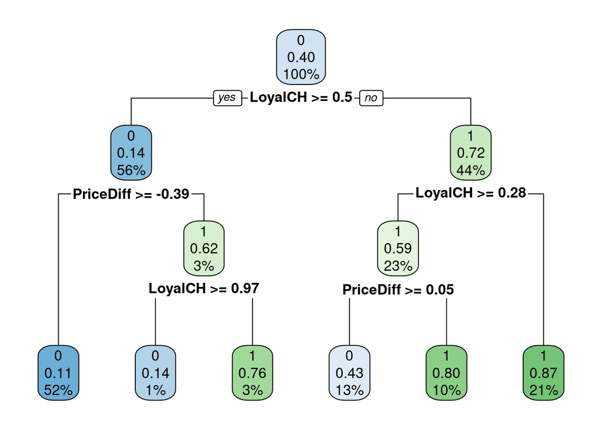

```r
rpart.plot(tree)
```

```r
head(predict(tree))
```

```
##           0         1
## 1 0.5658915 0.4341085
## 3 0.8928571 0.1071429
## 4 0.2021277 0.7978723
## 5 0.8928571 0.1071429
## 6 0.8928571 0.1071429
## 7 0.8928571 0.1071429
```

```r
head(predict(tree, type="class"))
```

```
## 1 3 4 5 6 7
## 0 0 1 0 0 0
## Levels: 0 1
```

```r
cmtree <- caret::confusionMatrix(predict(tree, type="class"),
                       ojsales_train$MM, positive = "1")
cmtree
```

```
## Confusion Matrix and Statistics
##
##           Reference
## Prediction   0   1
##          0 529 111
##          1  52 271
##
##                Accuracy : 0.8307
##                  95% CI : (0.8055, 0.8539)
##     No Information Rate : 0.6033
##     P-Value [Acc > NIR] : < 2.2e-16
##
##                   Kappa : 0.6368
##  Mcnemar's Test P-Value : 5.548e-06
##
##             Sensitivity : 0.7094
##             Specificity : 0.9105
##          Pos Pred Value : 0.8390
##          Neg Pred Value : 0.8266
##              Prevalence : 0.3967
##          Detection Rate : 0.2814
##    Detection Prevalence : 0.3354
##       Balanced Accuracy : 0.8100
##
##        'Positive' Class : 1
##
```

```r
tree.pred <- predict(tree, ojsales_test, type = "class")
```

```r
cmtree2 <- caret::confusionMatrix(tree.pred, ojsales_test$MM, positive = "1")
cmtree2
```

```
## Confusion Matrix and Statistics
##
##           Reference
## Prediction  0  1
##          0 69 11
##          1  3 24
##
##                Accuracy : 0.8692
##                  95% CI : (0.7902, 0.9266)
##     No Information Rate : 0.6729
##     P-Value [Acc > NIR] : 2.77e-06
##
##                   Kappa : 0.6842
##  Mcnemar's Test P-Value : 0.06137
##
##             Sensitivity : 0.6857
##             Specificity : 0.9583
##          Pos Pred Value : 0.8889
##          Neg Pred Value : 0.8625
##              Prevalence : 0.3271
##          Detection Rate : 0.2243
##    Detection Prevalence : 0.2523
##       Balanced Accuracy : 0.8220
##
##        'Positive' Class : 1
##
```

# Bootstrap Aggregation

```r
oj.bag <- randomForest(MM ~ StoreID + PriceCH + PriceMM + DiscCH + DiscMM + SpecialCH + SpecialMM + LoyalCH + SalePriceMM + SalePriceCH + PriceDiff + PctDiscMM + PctDiscCH + ListPriceDiff, data = ojsales_train, mtry=14, importance=TRUE, na.action = na.omit)

oj.bag
```

```
##
## Call:
##  randomForest(formula = MM ~ StoreID + PriceCH + PriceMM + DiscCH +      DiscMM + SpecialCH + SpecialMM + LoyalCH + SalePriceMM +      SalePriceCH + PriceDiff + PctDiscMM + PctDiscCH + ListPriceDiff,      data = ojsales_train, mtry = 14, importance = TRUE, na.action = na.omit)
##                Type of random forest: classification
##                      Number of trees: 500
## No. of variables tried at each split: 14
##
##         OOB estimate of  error rate: 22.22%
## Confusion matrix:
##     0   1 class.error
## 0 471 110   0.1893287
## 1 104 278   0.2722513
```

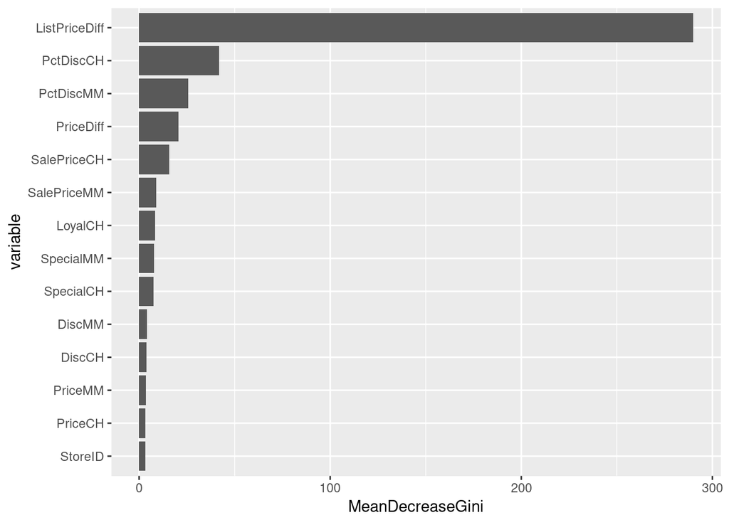

```r
oj_imp <- arrange(as.data.frame(oj.bag$importance),MeanDecreaseGini)
oj_imp$variable <- as.factor(names(oj.bag$importance[,1]))
oj_imp <- within(oj_imp, variable <- reorder(variable, MeanDecreaseGini))
ggplot(data = oj_imp) + geom_bar(aes(x=variable, y=MeanDecreaseGini), stat = "identity") + coord_flip()
```

```r
oj.bag.pred <- predict(oj.bag, ojsales_test, type="class" )
oj.bag.pred <- caret::confusionMatrix(oj.bag.pred, ojsales_test$MM, positive = "1")
oj.bag.pred
```

```
## Confusion Matrix and Statistics
##
##           Reference
## Prediction  0  1
##          0 61  9
##          1 11 26
##
##                Accuracy : 0.8131
##                  95% CI : (0.7262, 0.8819)
##     No Information Rate : 0.6729
##     P-Value [Acc > NIR] : 0.0009139
##
##                   Kappa : 0.5815
##  Mcnemar's Test P-Value : 0.8230633
##
##             Sensitivity : 0.7429
##             Specificity : 0.8472
##          Pos Pred Value : 0.7027
##          Neg Pred Value : 0.8714
##              Prevalence : 0.3271
##          Detection Rate : 0.2430
##    Detection Prevalence : 0.3458
##       Balanced Accuracy : 0.7950
##
##        'Positive' Class : 1
##
```

# Random Forest

```r
oj.rf <- randomForest(MM ~ StoreID + PriceCH + PriceMM + DiscCH + DiscMM + SpecialCH + SpecialMM + LoyalCH + SalePriceMM + SalePriceCH + PriceDiff + PctDiscMM + PctDiscCH + ListPriceDiff, data = ojsales_train, mtry = 4, importance = TRUE, na.action = na.omit)
```

```r
oj.rf
```

```
##
## Call:
##  randomForest(formula = MM ~ StoreID + PriceCH + PriceMM + DiscCH +      DiscMM + SpecialCH + SpecialMM + LoyalCH + SalePriceMM +      SalePriceCH + PriceDiff + PctDiscMM + PctDiscCH + ListPriceDiff,      data = ojsales_train, mtry = 4, importance = TRUE, na.action = na.omit)
##                Type of random forest: classification
##                      Number of trees: 500
## No. of variables tried at each split: 4
##
##         OOB estimate of  error rate: 19.11%
## Confusion matrix:
##     0   1 class.error
## 0 494  87   0.1497418
## 1  97 285   0.2539267
```

```r
oj.rf.pred <- predict(oj.rf, ojsales_test, type = "class")
cm.rf.pred <- caret::confusionMatrix(oj.rf.pred, ojsales_test$MM, positive = "1")
cm.rf.pred
```

```
## Confusion Matrix and Statistics
##
##           Reference
## Prediction  0  1
##          0 61  8
##          1 11 27
##
##                Accuracy : 0.8224
##                  95% CI : (0.7367, 0.8896)
##     No Information Rate : 0.6729
##     P-Value [Acc > NIR] : 0.0004081
##
##                   Kappa : 0.6053
##  Mcnemar's Test P-Value : 0.6463552
##
##             Sensitivity : 0.7714
##             Specificity : 0.8472
##          Pos Pred Value : 0.7105
##          Neg Pred Value : 0.8841
##              Prevalence : 0.3271
##          Detection Rate : 0.2523
##    Detection Prevalence : 0.3551
##       Balanced Accuracy : 0.8093
##
##        'Positive' Class : 1
##
```

# Summary

The obvious winner in terms of accuracy here was the logistic model which had a test accuracy score of 90%. That could be caused by a small sample size especially in the test dataset, which in turn causes variance in the preformance metric. I checked the signs of the coeficients and all of them had the expected sign in front of them so multicolinearity was not the culprit. There could be other cuases as well, the point being that the 90% shouldn’t be trusted as a reliable score on that model it is more likely that the structure of the data in the test data set played nice with the particular logistic model I made.

While I don’t completly trust the 90% of the logistic model, statistical methods should not be discounted just becuase there are new black box algorithims competing with them. In many cases a regression model with interaction terms and transformations can beat out a machine learning algorithim. Or an ensemble of regression models can be used to predict a numerical response variable where machine learning would fail.

## Sensitivity

Whats interesting here is that even though the simple decision tree had a high predicition score on the confusion matrix, it had the lowest sensitivity score. The Bootstrap Aggregation method came in third while the random forest and logrithmic methods tied for first with a score of .77.

## Accuracy: Training vs. Test

All of the models had a better test score than trainning score, so the log model is not alone in being able to predict the test dataset better, though it had the most dramatic difference between test and train. This could be cuased by the structual makeup of the test data, the size of the test data, or the size of the overall dataset.

## Overfitting

There was not any evidence of overfitting, in fact, we would have a hard time locating it as all of our test results were better than our train results. Our train results were not overly good, so I can’t say we have overfitting.

**HACKER EXTRA:** Try additional techniques such as random forest, k-nearest neighbor or others.

Then use the `predict()` function to make classification predictions on the test dataset and use `caret::confusionMatrix` to create a confusion matrix for each of the models for the predictions.

Summarize your results. - Which technique performed the best in terms of overall accuracy? - Which technique had the best sensitivity score? - How did accuracy differ for the training and test datasets for each model? - Is their any evidence of overfitting?